fossil

# Zinc binding from sequence, dug back up.

The authors' predictor is gone, so we rebuilt it from the paper and ran it again on the paper's own evaluation sets, with new sequence profiles. Of 38 results, 2 came back exactly, 6 agree, 14 partly agree, 5 cannot be told apart, 6 differ and 5 were not attempted.

See every result

## Fig. 1

Fig. 1. (a) P(X bound | Y bound) for C and H pairs within a separation d, with the prior; (b) correlation of the binding states of those pairs.

Agrees

Published

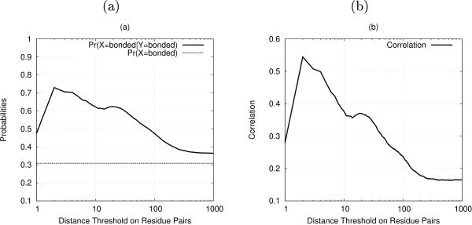

Our run

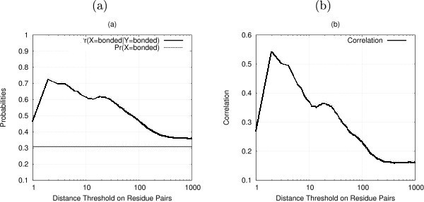

**Fig. 1a, P(X bound | Y bound) by separation**

95.4% within 2 px, Agrees

**Fig. 1b, correlation of binding states by separation**

87.1% within 2 px, Agrees

## Fig. 2

Fig. 2. Sites (a) and chains (b) that contain the semi-pattern [CHDE] x(0-7) [CHDE], overall and by site type.

Partly agrees

Published

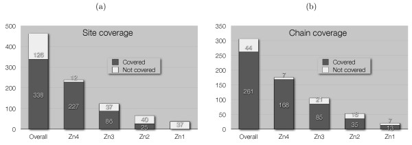

Our run

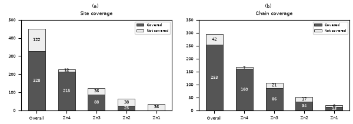

**Fig. 2a, semi-pattern coverage of sites**

3 of 10 values, Partly agrees

**Fig. 2b, semi-pattern coverage of chains**

3 of 10 values, Partly agrees

The not-covered bars come back within 4; the covered bars are short by the sites missing from Table 1 (Zn4 215 against 227). Within 2 of every bar except the covered ones overall (253 against 261) and in Zn4 (160 against 168), where the missing Zn4 chains are.

## Fig. 3

Fig. 3. Leave-one-out, residue level: recall-precision of the local CH-SVM and the gated SPCH-SVM, (a) C and H, (b) C, (c) H.

Differs

Published

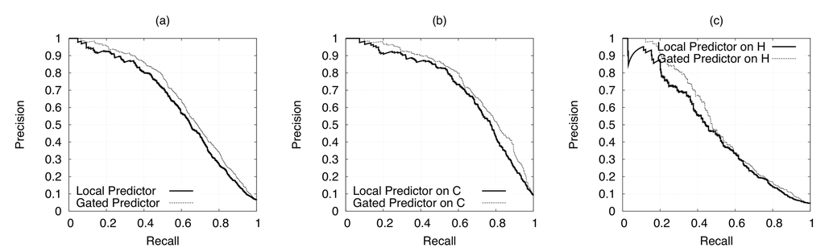

Our run

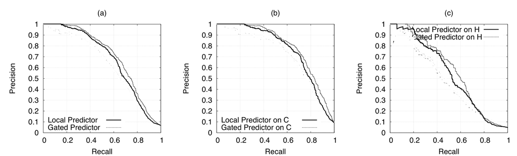

**Fig. 3a, Leave-one-out, residue level, C and H**

8.2% within 2 px, Inconclusive

**Fig. 3b, Leave-one-out, residue level, C**

11.8% within 2 px, Differs

**Fig. 3c, Leave-one-out, residue level, H**

14.5% within 2 px, Partly agrees

The profiles are not the paper's: the 2005 nr is gone, so ours come from UniRef100 of 2010 with unstated PSI-BLAST settings, and the SVM and Platt parameters tuned on the old profiles were kept. The labels, folds and residues are the paper's own.

## Fig. 4

Fig. 4. Five-fold CV by SCOP superfamily, residue level: local against gated, (a) C and H, (b) C, (c) H.

Inconclusive

Published

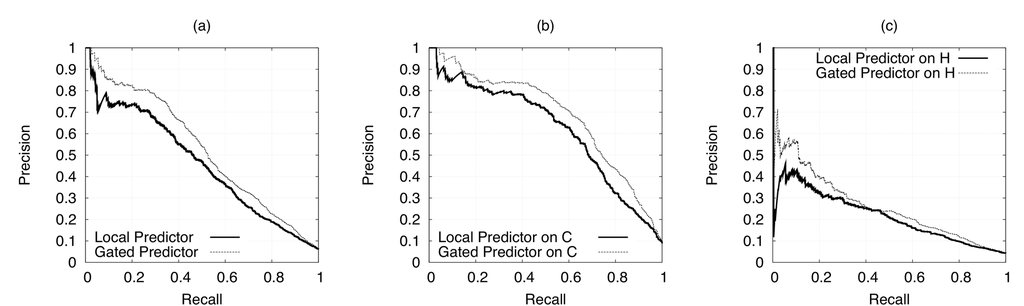

Our run

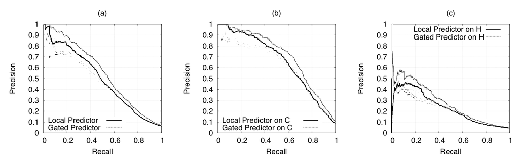

**Fig. 4a, Five-fold CV, residue level, C and H**

14.1% within 2 px, Partly agrees

**Fig. 4b, Five-fold CV, residue level, C**

12.0% within 2 px, Inconclusive

**Fig. 4c, Five-fold CV, residue level, H**

39.2% within 2 px, Partly agrees

The profiles are not the paper's: the 2005 nr is gone, so ours come from UniRef100 of 2010 with unstated PSI-BLAST settings, and the SVM and Platt parameters tuned on the old profiles were kept. The labels, folds and residues are the paper's own.

## Fig. 5

Fig. 5. Leave-one-out, protein level: (a) all chains, (b) by zinc site type, (c) Zn3 chains, SPCH against SPCHDE.

Partly agrees

Published

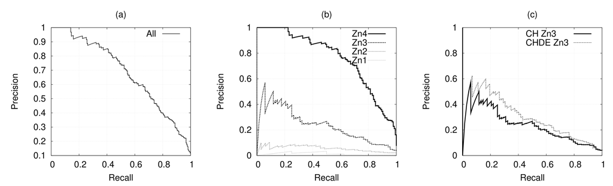

Our run

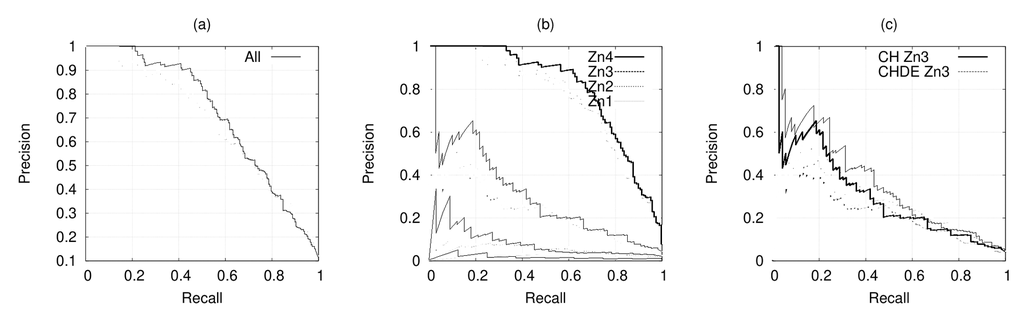

**Fig. 5a, Leave-one-out, protein level, all chains**

15.1% within 2 px, Partly agrees

**Fig. 5b, Leave-one-out, protein level, by site type**

20.3% within 2 px, Partly agrees

**Fig. 5c, Leave-one-out, protein level, Zn3, SPCH against SPCHDE**

14.3% within 2 px, Partly agrees

The residue-level probabilities behind these curves come from our profiles (see Figs 3 and 4); the chain call and the site types are as the text describes.

## Fig. 6

Fig. 6. Five-fold CV, protein level: (a) all chains, (b) by zinc site type, (c) Zn3 chains, SPCH against SPCHDE.

Inconclusive

Published

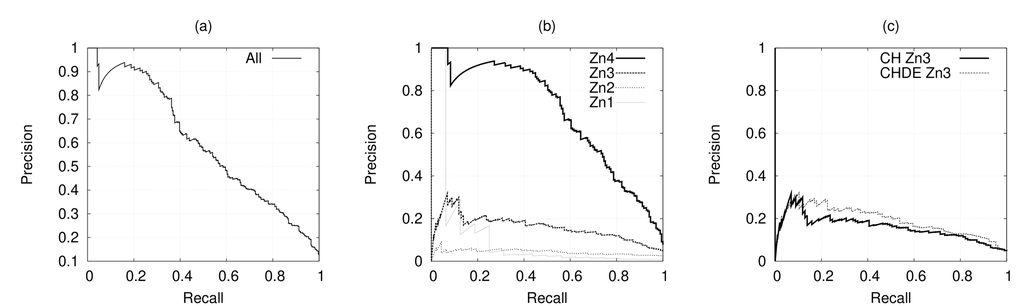

Our run

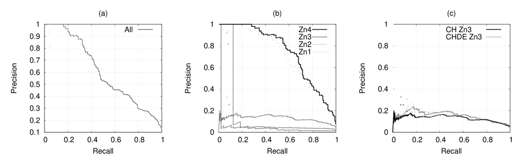

**Fig. 6a, Five-fold CV, protein level, all chains**

14.2% within 2 px, Inconclusive

**Fig. 6b, Five-fold CV, protein level, by site type**

23.4% within 2 px, Inconclusive

**Fig. 6c, Five-fold CV, protein level, Zn3, SPCH against SPCHDE**

19.1% within 2 px, Inconclusive

The residue-level probabilities behind these curves come from our profiles (see Figs 3 and 4); the chain call and the site types are as the text describes.

## Every result

Every figure panel, table and number of the paper, in the paper's order. Paper and ours are both shown; the verdict is computed from them.

Result

Verdict

Measure

Why

Table 1, zinc site types

Partly agrees

11 of 21 values

- Zn1 sites: paper 37, ours **36**
- Zn1 chains: paper 20, ours **19**
- Zn2 sites: paper 65, ours **63**
- Zn2 chains: paper 53, ours **51**
- Zn3 sites: paper 123, ours **124**
- Zn3 chains: paper 106, ours **107**
- Zn4 sites: paper 239, ours **227**
- Zn4 chains: paper 175, ours **167**
- Any sites: paper 464, ours **450**
- Any chains: paper 305, ours **295**
- chains with site types {1,2}: paper 14, ours **14**
- chains with site types {1,3}: paper 9, ours **9**
- chains with site types {1,4}: paper 3, ours **3**
- chains with site types {2,3}: paper 21, ours **21**
- chains with site types {2,4}: paper 4, ours **4**
- chains with site types {3,4}: paper 8, ours **8**
- chains with site types {1,2,3}: paper 7, ours **7**
- chains with site types {1,2,4}: paper 1, ours **1**
- chains with site types {1,3,4}: paper 0, ours **0**
- chains with site types {2,3,4}: paper 2, ours **2**
- chains with site types {1,2,3,4}: paper 0, ours **0**

We count 450 sites in 295 chains against 464 in 305. Additional file 1 lists 296 of the 305 zinc chains, and in one of those (1H79) the metal is now modelled as iron. The deficit sits almost all in Zn4 (12 sites, 8 chains). With the donor atoms restricted to side chains of C, H, D, E, N and Q, the multiple-site-type counts of Table 1 come back exactly.

Table 2, ligand residues by site type

Partly agrees

30 of 83 values

- C Zn4 Na: paper 663, ours **625**
- C Zn4 fa: paper 69.3, ours **68.8**
- C Zn4 fs: paper 91.8, ours **91.2**
- C Zn3 Na: paper 45, ours **46**
- C Zn3 fa: paper 12.2, ours **12.4**
- C Zn3 fs: paper 6.2, ours **6.7**
- C Zn2 Na: paper 10, ours **10**
- C Zn2 fa: paper 7.7, ours **7.9**
- C Zn2 fs: paper 1.4, ours **1.5**
- C Zn1 Na: paper 4, ours **4**
- C Zn1 fa: paper 10.8, ours **11.1**
- C Zn1 fs: paper 0.6, ours **0.6**
- C All: paper 722, ours **685**
- H Zn4 Na: paper 220, ours **211**
- H Zn4 fa: paper 23.0, ours **23.2**
- H Zn4 fs: paper 45.7, ours **44.5**
- H Zn3 Na: paper 194, ours **196**
- H Zn3 fa: paper 52.6, ours **52.7**
- H Zn3 fs: paper 40.3, ours **41.4**
- H Zn2 Na: paper 59, ours **59**
- H Zn2 fa: paper 45.4, ours **46.8**
- H Zn2 fs: paper 12.3, ours **12.4**
- H Zn1 Na: paper 8, ours **8**
- H Zn1 fa: paper 21.6, ours **22.2**
- H Zn1 fs: paper 1.7, ours **1.7**
- H All: paper 481, ours **474**
- D Zn4 Na: paper 48, ours **48**
- D Zn4 fa: paper 5.0, ours **5.3**
- D Zn4 fs: paper 27.6, ours **28.1**
- D Zn3 Na: paper 83, ours **83**
- D Zn3 fa: paper 22.5, ours **22.3**
- D Zn3 fs: paper 47.7, ours **48.5**
- D Zn2 Na: paper 30, ours **27**
- D Zn2 fa: paper 23.1, ours **21.4**
- D Zn2 fs: paper 17.2, ours **15.8**
- D Zn1 Na: paper 13, ours **13**
- D Zn1 fa: paper 35.1, ours **36.1**
- D Zn1 fs: paper 7.5, ours **7.6**
- D All: paper 174, ours **171**
- E Zn4 Na: paper 18, ours **17**
- E Zn4 fa: paper 1.9, ours **1.9**
- E Zn4 fs: paper 17.5, ours **16.8**
- E Zn3 Na: paper 46, ours **46**
- E Zn3 fa: paper 12.5, ours **12.4**
- E Zn3 fs: paper 44.7, ours **45.5**
- E Zn2 Na: paper 28, ours **28**
- E Zn2 fa: paper 21.5, ours **22.2**
- E Zn2 fs: paper 27.2, ours **27.7**
- E Zn1 Na: paper 11, ours **10**
- E Zn1 fa: paper 29.7, ours **27.8**
- E Zn1 fs: paper 10.7, ours **9.9**
- E All: paper 103, ours **101**
- N Zn4 Na: paper 5, ours **5**
- N Zn4 fa: paper 0.5, ours **0.6**
- N Zn4 fs: paper 83.3, ours **100**
- N Zn3 Na: paper 0, ours **0**
- N Zn3 fa: paper 0.0, ours **0**
- N Zn3 fs: paper 0.0, ours **0**
- N Zn2 Na: paper 1, ours **0**
- N Zn2 fa: paper 0.8, ours **0**
- N Zn2 fs: paper 16.7, ours **0**
- N Zn1 Na: paper 0, ours **0**
- N Zn1 fa: paper 0.0, ours **0**
- N Zn1 fs: paper 0.0, ours **0**
- N All: paper 6, ours **5**
- Q Zn4 Na: paper 2, ours **2**
- Q Zn4 fa: paper 0.2, ours **0.2**
- Q Zn4 fs: paper 33.3, ours **33.3**
- Q Zn3 Na: paper 1, ours **1**
- Q Zn3 fa: paper 0.3, ours **0.3**
- Q Zn3 fs: paper 16.7, ours **16.7**
- Q Zn2 Na: paper 2, ours **2**
- Q Zn2 fa: paper 1.5, ours **1.6**
- Q Zn2 fs: paper 33.3, ours **33.3**
- Q Zn1 Na: paper 1, ours **1**
- Q Zn1 fa: paper 2.7, ours **2.8**
- Q Zn1 fs: paper 16.7, ours **16.7**
- Q All: paper 6, ours **6**
- Total Zn4: paper 956, ours **908**
- Total Zn3: paper 369, ours **372**
- Total Zn2: paper 130, ours **126**
- Total Zn1: paper 37, ours **36**
- Total All: paper 1492, ours **1442**

Same sites as Table 1: 1,442 ligands against 1,492, short mostly in Zn4 cysteines (625 against 663), which the missing chains would hold.

Table 3, binding-site patterns

Partly agrees

5 of 18 values

- [CHDE] x(.) [CHDE] x(.) [CHDE] x(.) [CHDE]: paper 232, ours **220**
- [CH] x(.) [CH] x(.) [CH] x(.) [CH]: paper 196, ours **185**
- [CHDE] x(0-7) [CHDE] x(.) [CHDE] x(0-7) [CHDE]: paper 161, ours **155**
- [CHDE] x(0-7) [CHDE] x(>7) [CHDE] x(0-7) [CHDE]: paper 141, ours **135**
- [CHDE] x(.) [CHDE] x(.) [CHDE]: paper 122, ours **123**
- [C] x(.) [C] x(.) [C] x(.) [C]: paper 85, ours **79**
- [CHDE] x(.) [CHDE]: paper 62, ours **61**
- [CHDE] x(0-7) [CHDE] x(>7) [CHDE]: paper 55, ours **55**
- [CH] x(.) [CH] x(.) [CH]: paper 37, ours **38**
- [CHDE] x(>7) [CHDE] x(0-7) [CHDE]: paper 24, ours **25**
- [CH] x(.) [CH]: paper 21, ours **21**
- [CHDE] x(0-7) [CHDE] x(>7) [CHDE] x(>7) [CHDE]: paper 17, ours **17**
- [CHDE] x(>7) [CHDE] x(0-7) [CHDE] x(0-7) [CHDE]: paper 16, ours **14**
- [DE] x(.) [DE]: paper 15, ours **14**
- [DE] x(.) [DE] x(.) [DE]: paper 10, ours **10**
- [CHDE] x(>7) [CHDE] x(>7) [CHDE] x(0-7) [CHDE]: paper 10, ours **8**
- [CHDE] x(0-7) [CHDE] x(0-7) [CHDE] x(>7) [CHDE]: paper 8, ours **7**
- [DE] x(.) [DE] x(.) [DE] x(.) [DE]: paper 1, ours **1**

Same sites as Table 1. 5 of 18 counts are equal; the four-ligand patterns are short by up to 12, as the Zn4 sites are.

Fig. 1a, P(X bound | Y bound) by separation

Agrees

95.4% within 2 px

Fig. 1b, correlation of binding states by separation

Agrees

87.1% within 2 px

Fig. 2a, semi-pattern coverage of sites

Partly agrees

3 of 10 values

- Overall covered: paper 338, ours **328**
- Overall not covered: paper 126, ours **122**
- Zn4 covered: paper 227, ours **215**
- Zn4 not covered: paper 12, ours **12**
- Zn3 covered: paper 86, ours **88**
- Zn3 not covered: paper 37, ours **36**
- Zn2 covered: paper 25, ours **25**
- Zn2 not covered: paper 40, ours **38**
- Zn1 covered: paper 0, ours **0**
- Zn1 not covered: paper 37, ours **36**

The not-covered bars come back within 4; the covered bars are short by the sites missing from Table 1 (Zn4 215 against 227).

Fig. 2b, semi-pattern coverage of chains

Partly agrees

3 of 10 values

- Overall covered: paper 261, ours **253**
- Overall not covered: paper 44, ours **42**
- Zn4 covered: paper 168, ours **160**
- Zn4 not covered: paper 7, ours **7**
- Zn3 covered: paper 85, ours **86**
- Zn3 not covered: paper 21, ours **21**
- Zn2 covered: paper 35, ours **34**
- Zn2 not covered: paper 18, ours **17**
- Zn1 covered: paper 13, ours **13**
- Zn1 not covered: paper 7, ours **6**

Within 2 of every bar except the covered ones overall (253 against 261) and in Zn4 (160 against 168), where the missing Zn4 chains are.

Fig. 3a, Leave-one-out, residue level, C and H

Inconclusive

8.2% within 2 px

The profiles are not the paper's: the 2005 nr is gone, so ours come from UniRef100 of 2010 with unstated PSI-BLAST settings, and the SVM and Platt parameters tuned on the old profiles were kept. The labels, folds and residues are the paper's own.

Fig. 3b, Leave-one-out, residue level, C

Differs

11.8% within 2 px

The profiles are not the paper's: the 2005 nr is gone, so ours come from UniRef100 of 2010 with unstated PSI-BLAST settings, and the SVM and Platt parameters tuned on the old profiles were kept. The labels, folds and residues are the paper's own.

Fig. 3c, Leave-one-out, residue level, H

Partly agrees

14.5% within 2 px

The profiles are not the paper's: the 2005 nr is gone, so ours come from UniRef100 of 2010 with unstated PSI-BLAST settings, and the SVM and Platt parameters tuned on the old profiles were kept. The labels, folds and residues are the paper's own.

Fig. 4a, Five-fold CV, residue level, C and H

Partly agrees

14.1% within 2 px

The profiles are not the paper's: the 2005 nr is gone, so ours come from UniRef100 of 2010 with unstated PSI-BLAST settings, and the SVM and Platt parameters tuned on the old profiles were kept. The labels, folds and residues are the paper's own.

Fig. 4b, Five-fold CV, residue level, C

Inconclusive

12.0% within 2 px

The profiles are not the paper's: the 2005 nr is gone, so ours come from UniRef100 of 2010 with unstated PSI-BLAST settings, and the SVM and Platt parameters tuned on the old profiles were kept. The labels, folds and residues are the paper's own.

Fig. 4c, Five-fold CV, residue level, H

Partly agrees

39.2% within 2 px

The profiles are not the paper's: the 2005 nr is gone, so ours come from UniRef100 of 2010 with unstated PSI-BLAST settings, and the SVM and Platt parameters tuned on the old profiles were kept. The labels, folds and residues are the paper's own.

Fig. 5a, Leave-one-out, protein level, all chains

Partly agrees

15.1% within 2 px

The residue-level probabilities behind these curves come from our profiles (see Figs 3 and 4); the chain call and the site types are as the text describes.

Fig. 5b, Leave-one-out, protein level, by site type

Partly agrees

20.3% within 2 px

The residue-level probabilities behind these curves come from our profiles (see Figs 3 and 4); the chain call and the site types are as the text describes.

Fig. 5c, Leave-one-out, protein level, Zn3, SPCH against SPCHDE

Partly agrees

14.3% within 2 px

The residue-level probabilities behind these curves come from our profiles (see Figs 3 and 4); the chain call and the site types are as the text describes.

Fig. 6a, Five-fold CV, protein level, all chains

Inconclusive

14.2% within 2 px

The residue-level probabilities behind these curves come from our profiles (see Figs 3 and 4); the chain call and the site types are as the text describes.

Fig. 6b, Five-fold CV, protein level, by site type

Inconclusive

23.4% within 2 px

The residue-level probabilities behind these curves come from our profiles (see Figs 3 and 4); the chain call and the site types are as the text describes.

Fig. 6c, Five-fold CV, protein level, Zn3, SPCH against SPCHDE

Inconclusive

19.1% within 2 px

The residue-level probabilities behind these curves come from our profiles (see Figs 3 and 4); the chain call and the site types are as the text describes.

Fig. 7, previously known human zinc proteins retrieved, by reliability level

Not attempted

Needs the reliability level of each of the 3,207 proteins of Andreini et al. 2006, which is only in that paper's paywalled Supporting Information (HTTP 403 to a scripted client). Additional file 3 gives only yes or no.

Fig. 8, predicted probabilities of the four cysteines of NP_060357.1

Differs

0 of 4 values

- Cys31 (NP_060357.1 Cys33): paper 0.90, ours **0.81**
- Cys34 (NP_060357.1 Cys36): paper 0.98, ours **0.82**
- Cys65 (NP_060357.1 Cys67): paper 0.67, ours **0.48**
- Cys68 (NP_060357.1 Cys70): paper 0.82, ours **0.54**

Our probabilities rank the same four cysteines highest (0.81, 0.82, 0.48 and 0.54; the paper 0.90, 0.98, 0.67 and 0.82) but run lower, as across the proteome, so only two pass 0.7 and the protein is not called; with refitted Platt constants 0.85, 0.86, 0.56 and 0.62.

Fig. 8, homology model of NP_060357.1

Not attempted

A rendered homology model (Modeller 6v2 on PDB 1ZSO); it shows that the cysteines are close, which the crystal structure 5ZLQ of the same protein, released in 2018, now shows directly (item later.czib).

Fig. 9, predicted probabilities of the four cysteines of the XP_374396 UCH domain

Differs

0 of 4 values

- Cys140 (XP_374396.2 Cys372): paper 0.99, ours **0.54**
- Cys143 (XP_374396.2 Cys375): paper 0.99, ours **0.81**
- Cys187 (XP_374396.2 Cys419): paper 0.99, ours **0.98**
- Cys190 (XP_374396.2 Cys422): paper 0.99, ours **0.95**

The last two cysteines come back at 0.98 and 0.95 (paper 0.99); the first two are lower (0.54 and 0.81), as our probabilities are across the proteome.

Fig. 9, homology model of the XP_374396 UCH domain

Not attempted

A rendered homology model whose template the paper does not name; the zinc site it shows is confirmed by the later structure of a family member (item later.usp).

Text, evaluation sets (305 + 2,369 chains; LOO 230 + 1,949; 38 removed from CV)

Differs

0 of 6 values

- zinc chains: paper 305, ours **296**
- chains without metal: paper 2369, ours **2162**
- LOO zinc chains: paper 230, ours **221**
- LOO chains without metal: paper 1949, ours **1756**
- CV zinc chains: paper 305, ours **296**
- CV chains without metal (2,369 - 38): paper 2331, ours **2132**

Additional file 1 lists only chains with at least one C, H, D or E residue that passed the profile filter (its README says so), so it has fewer chains than the text: 296 and 2,162 against 305 and 2,369.

Text claims recomputed from the paper's own tables and Additional file 3

Agrees

Text, Leave-one-out: AURPC and AUC of the local and gated predictors

Partly agrees

1 of 6 values

- local AURPC: paper 0.590, ours **0.678**
- gated AURPC: paper 0.633, ours **0.709**
- local AUC: paper 0.895, ours **0.893**
- local AUC SE: paper 0.007, ours **0.007**
- gated AUC: paper 0.914, ours **0.913**
- gated AUC SE: paper 0.006, ours **0.007**

The AUCs come back within 0.002 and the local standard error at the printed 0.007 (gated 0.007 against 0.006); our AURPCs are higher (0.678 and 0.709 against 0.590 and 0.633). Our profiles are not the paper's; the printed AURPCs are also 0.033 below the area under the paper's own curves.

Text, Five-fold CV: AURPC and AUC of the local and gated predictors

Partly agrees

1 of 6 values

- local AURPC: paper 0.428, ours **0.494**
- gated AURPC: paper 0.500, ours **0.552**
- local AUC: paper 0.867, ours **0.852**
- local AUC SE: paper 0.007, ours **0.007**
- gated AUC: paper 0.890, ours **0.877**
- gated AUC SE: paper 0.006, ours **0.007**

Our AURPCs are higher (0.494 and 0.552 against 0.428 and 0.500) and our AUCs lower (0.852 and 0.877 against 0.867 and 0.890). Our profiles are not the paper's; the printed AURPCs are also 0.031 to 0.034 below the area under the paper's own curves.

Text, main claim: the gated SP-SVM beats the local SVM, significantly

Exact

9 of 9 values

- LOO, gated AURPC above local: paper yes, ours **yes**
- LOO, gated AUC above local: paper yes, ours **yes**
- LOO, AUC difference larger than the two SEs: paper yes, ours **yes**
- LOO, gated above local on C: paper yes, ours **yes**
- LOO, gated above local on H: paper yes, ours **yes**
- LOO, cysteines better predicted than histidines: paper yes, ours **yes**
- CV, gated AURPC above local: paper yes, ours **yes**
- CV, gated AUC above local: paper yes, ours **yes**
- CV, AUC difference larger than the two SEs: paper yes, ours **yes**

Text, SPCHDE-SVM: AUC on aspartate and glutamate

Partly agrees

10 of 12 values

- LOO D AUC: paper 0.74, ours **0.74**
- LOO D SE: paper 0.03, ours **0.03**
- LOO E AUC: paper 0.70, ours **0.7**
- LOO E SE: paper 0.06, ours **0.06**
- CV D AUC: paper 0.73, ours **0.7**
- CV D SE: paper 0.03, ours **0.03**
- CV E AUC: paper 0.65, ours **0.63**
- CV E SE: paper 0.05, ours **0.05**
- LOO, D better than random (AUC - 2 SE above 0.5): paper yes, ours **yes**
- LOO, E better than random: paper yes, ours **yes**
- CV, D better than random: paper yes, ours **yes**
- CV, E better than random: paper yes, ours **yes**

The profiles are not the paper's: the 2005 nr is gone, so ours come from UniRef100 of 2010 with unstated PSI-BLAST settings, and the SVM and Platt parameters tuned on the old profiles were kept. The labels, folds and residues are the paper's own.

Text, protein level: Zn4 easiest; SPCHDE better than SPCH only on Zn3

Exact

4 of 4 values

- LOO, Zn4 chains easiest: paper yes, ours **yes**
- CV, Zn4 chains easiest: paper yes, ours **yes**
- LOO, SPCHDE above SPCH on Zn3 chains: paper yes, ours **yes**
- CV, SPCHDE above SPCH on Zn3 chains: paper yes, ours **yes**

Text, human proteome scan (RefSeq Build 35.1)

Differs

0 of 3 values

- zinc-binding chains predicted: paper 2833, ours **2010**
- of the 3,207 previous ones, not confirmed: paper 965, ours **1314**
- new predictions (about 600): paper 600, ours **118**

Our predictor calls fewer human proteins: in the sample it recovers 81 of the 100 proteins both methods called and 10 of the 50 only the SPCH-SVM called, so the estimate is 2,010 (SE 101) against 2,833. Refitting the Platt constants to our own CV margins raises it to 2,223 (SE 94); the rest is open.

Text, examples: ubiquitin-specific proteases and ADAM-TS

Differs

0 of 2 values

- USP chains with a predicted CX2CX(43-50)CX2C (about 50): paper 50, ours **2**
- ADAM-TS: mean probability of the third histidine of HX3HX5H: paper 0.32, ours **0.21**

Only 2 of the 65 proteases get all four cysteines of a CX2CX(43-50)CX2C above 0.7 (38 are called zinc-binding); in ADAM-TS the third histidine is low (mean 0.21, against 0.32) and the first two are above 0.7 in 15 of 25. Our probabilities run lower, as in the proteome count.

Text, the 350 and 100 previously known chains not retrieved; 53% and 76%

Not attempted

These counts need the per-protein reliability levels of Andreini et al. 2006 (as Fig. 7).

Later structure: zinc site of NP_060357.1 (CZIB) in PDB 5ZLQ

Agrees

Later structure: CX2CX43CX2C zinc site of a UBP-family protease in PDB 2HD5

Agrees

The authors' predictor (Zinc Finder, C++)

Not attempted

The project page (zincfinder.dsi.unifi.it) now returns a 'Resource not found' page and no copy of the code was found; the method is implemented from the paper's text.

Python package spsvm and its tutorial

Agrees

The paper's main claim holds: the gated predictor beats the local one in both tests, on cysteines and on histidines, and overall by more than the error bars. The AURPCs, the proteome count and the single probabilities do not come back; the likely causes, still open, are our 2010 profiles in place of the lost 2005 ones and the Platt constants tuned on those.

## What came back

**The zinc sites**

From today's PDB files the multiple-site-type counts of Table 1 come back exactly, once only side-chain donors of six residue types count.

**Fig. 1**

The correlation curves overlay the published ones, read as C and H pairs counted by the residues between them.

**The main claim**

Gated beats local in leave-one-out and in CV, on C and on H. The leave-one-out AUCs are 0.893 and 0.913 (paper 0.895 and 0.914).

**D and E**

The leave-one-out AUCs of aspartate and glutamate come back as printed: 0.74 and 0.70.

**Fig. 8's protein**

A 2018 crystal structure (5ZLQ) binds zinc with exactly the four cysteines the paper predicted, the one at 0.67 included. Our predictor ranks the same four highest.

**The paper's own arithmetic**

Its proteome counts (2,833 predicted, 965 of 3,207 not confirmed, 591 new) follow from its Additional file 3; our own scan predicts about 2,010.

## What stayed buried

- The authors' C++ predictor and its 2005 profiles
- Nine of the 305 zinc chains, absent from Additional file 1
- The reliability levels behind Fig. 7, in a paywalled supplement
- How the printed AURPCs were computed: they sit 0.033 below the paper's own curves

The paper's main claim holds: the gated predictor beats the local one in both tests, on cysteines and on histidines, and overall by more than the error bars. The AURPCs, the proteome count and the single probabilities do not come back; the likely causes, still open, are our 2010 profiles in place of the lost 2005 ones and the Platt constants tuned on those.

## What we matched

Where our numbers sit against the paper's.

**Leave-one-out AUC**

0.893 and 0.913 against 0.895 and 0.914

**CV AUC**

0.852 and 0.877 against 0.867 and 0.890

**Leave-one-out AURPC**

0.678 and 0.709 against 0.590 and 0.633

**Human zinc proteins**

about 2,010 against 2,833